# R Bootcamp 2.5 the t-test

last updated: 2021-11-02

> The t-test and t-distribution are widely considered to be at the very foundation of statistics. Who would believe they were invented to make great beer better?

-The t-test invented by William Gosset (‘Student’), Guiness Brewery

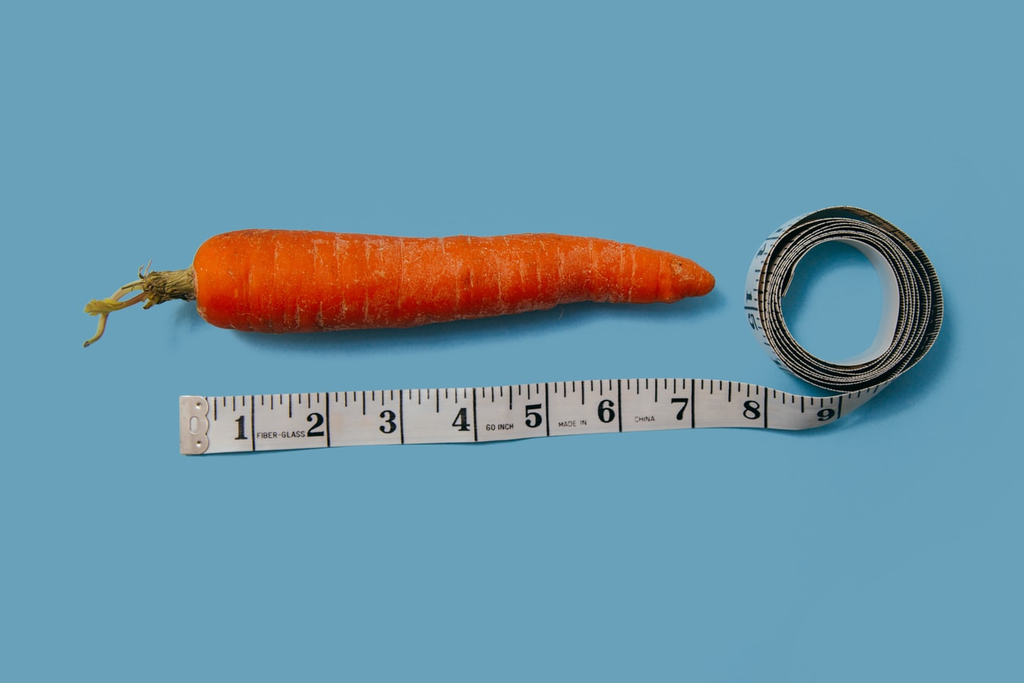

## T-test

**The t-test** is a foundational tool for scientists

- Compare mean differences (2 sample)
- 1-sample difference
- Paired sample differences…

## What you will learn

- The question of the t-test
- Data and assumptions
- Graphing
- Tests and alternatives
- Practice exercises

## The question of the t-test

“2 sample test”

The main question is did these 2 samples come from populations with different means?

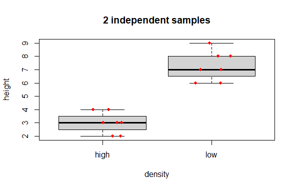

## The question of the t-test

“1 sample test”

The main question is did this 1 sample come from population of a known mean?

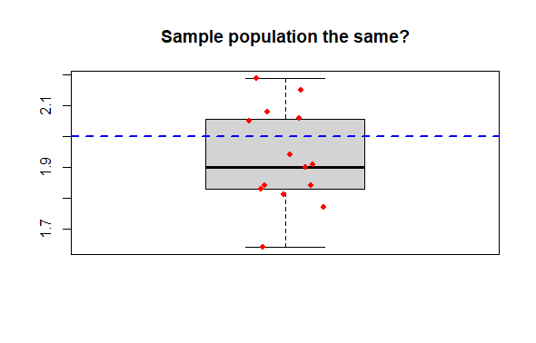

## The question of the t-test

“paired sample test”

Is there a consistent difference between paired sample observations?

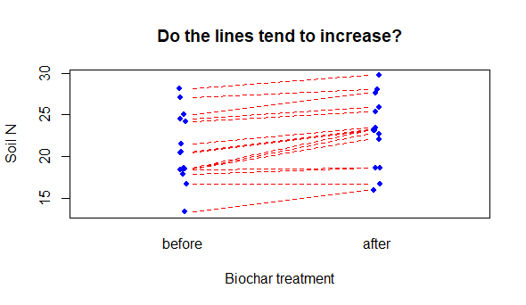

## Data and assumptions

Formal assumptions

- Gaussian residuals (for EACH SAMPLE)
- Heteroscedasticity
- Independence of observations

## Data and assumptions

Informal assumptions (the ones we have responsibility to evaluate)

- Gaussian distribution (for EACH SAMPLE)
- Heteroscedasticity (in practice we account for this difference with math by using the pooled SD)
- Independence of observations (if this is not true, perhaps paired samples is appropriate)

## Data and assumptions

Example of mean human height by sex

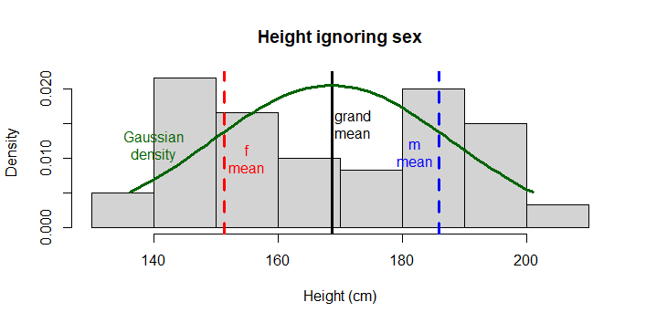

## Data and assumptions

Iris data

```r
data(iris)
names(iris)
```

```
## [1] "Sepal.Length" "Sepal.Width"  "Petal.Length" "Petal.Width"  "Species"
```

## Data and assumptions

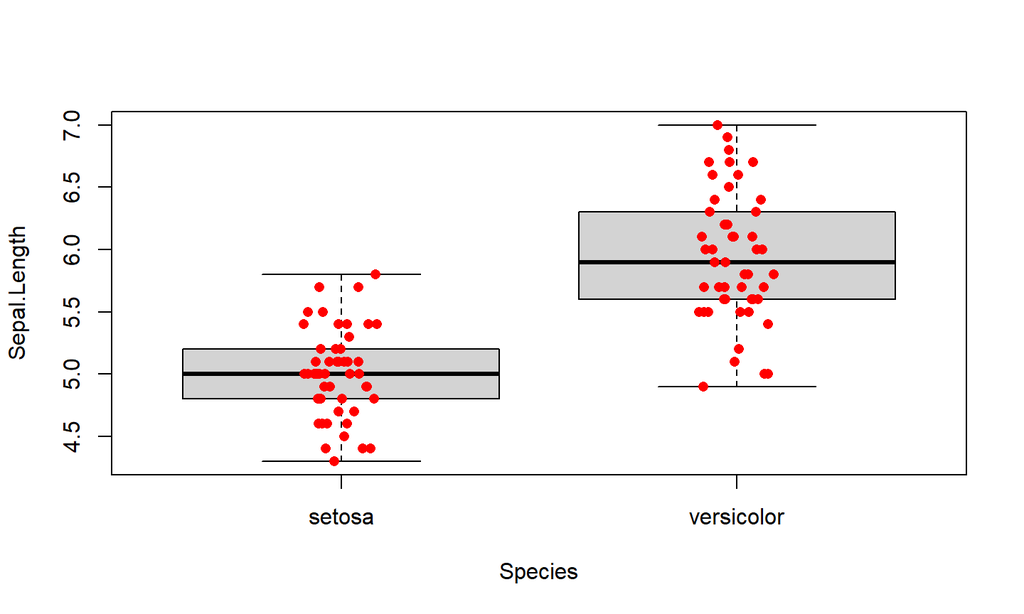

```r
iris2 <- iris[1:100, c(1,5)]
iris2$Species <-droplevels(iris2$Species)
boxplot(Sepal.Length~Species, data = iris2)
stripchart(Sepal.Length~Species, data = iris2,
           pch = 16, col = 'red', vertical = T,
           add = T, method = 'jitter')
```

## Data and assumptions

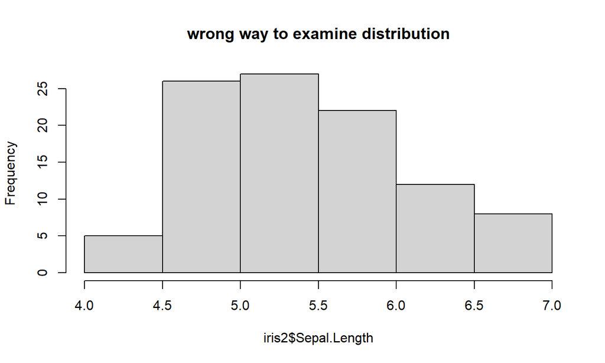

```r
hist(iris2$Sepal.Length,
     main = 'wrong way to examine distribution')
```

## Data and assumptions

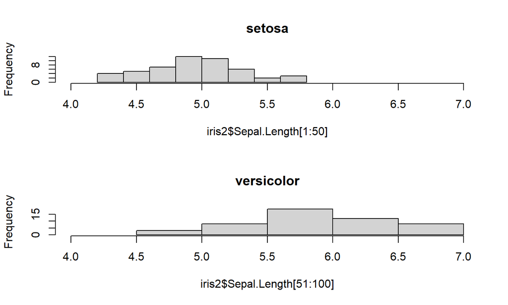

```r
par(mfrow = c(2,1))

hist(iris2$Sepal.Length[1:50], xlim = c(4,7), main = 'setosa')
hist(iris2$Sepal.Length[51:100], xlim = c(4,7), main = 'versicolor')
```

## Data and assumptions

## Data and assumptions

Slice out perch

## Live coding

[figure not shown]